# Differential privacy as randomized responses

Thom Volker

Utrecht University

08-08-2022

Randomized responses can be seen as differentially private, because individuals are protected by “plausible deniability”. Each person can argue that the response is not correct, because the answer is due to a random coin flip.

So, let’s consider a data set in which the sensitive question ‘have you ever used harddrugs?’ is recorded for $n = 2000$ observations. For each observation $i = 1, 2, \dots, n$, the truthful answer is caputed in the data.

That is, we have the data

```r
set.seed(123)
drugs <- rbinom(2000, 1, 0.3)
```

We can make the query “what proportion of the sample uses harddrugs?” differentially private by adding noise to the results of this query. Noise can be added by making use of a coin flip: for each observation $i$, we flip an unfair coin, with probability of getting heads equal to $P(head) = p_1$. If the coin comes up head, we leave the truthful answer as is. If the coin comes up tail, we another coin, with probability of heads $P(head) = p_2 = 0.5$. If head comes up, we report $1 = \text{Yes}$, if tail comes up, we return the answer $0 = \text{No}$. Now, the user is protected by the probability $p_1$. If $p_1$ equals $1$, only true answers are used to return the data, but if $p_1 < 1$, there is a probability $(1 - p_1)$ that the used response answer is the result of a random coin flip.

[figure not shown]

```r
library(purrr)
library(ggplot2)
library(gganimate)
library(tibble)

dp <- function(responses, p1, p2) {
  n      <- length(responses)
  keep   <- rbinom(n, 1, p1)
  change <- rbinom(n, 1, p2)
  ifelse(keep == 1, responses, change)
}

prop_drugs <- function(dp, p1, p2) {
  (mean(dp) - (1 - p1) * p2) / p1
}


tibble(`Pr(heads)` = seq(0.00, 1, 0.001),
       `Pr(drugs)` = map_dbl(`Pr(heads)`,
                             ~ dp(drugs, .x, 0.5) %>%
                               prop_drugs(.x, 0.5))) %>%
  ggplot(aes(x = `Pr(heads)`, y = `Pr(drugs)`)) +
  geom_hline(yintercept = mean(drugs), alpha = 0.2) +
  geom_line(aes(group = 1, col = `Pr(drugs)`), size = 0.5) +
  theme_classic() +
  ylim(0,1) +
  transition_reveal(`Pr(heads)`) +
  theme(legend.position = "none")
```

The less noise we add, the closer we come to the true population estimate, and the less variance around this estimate there is.

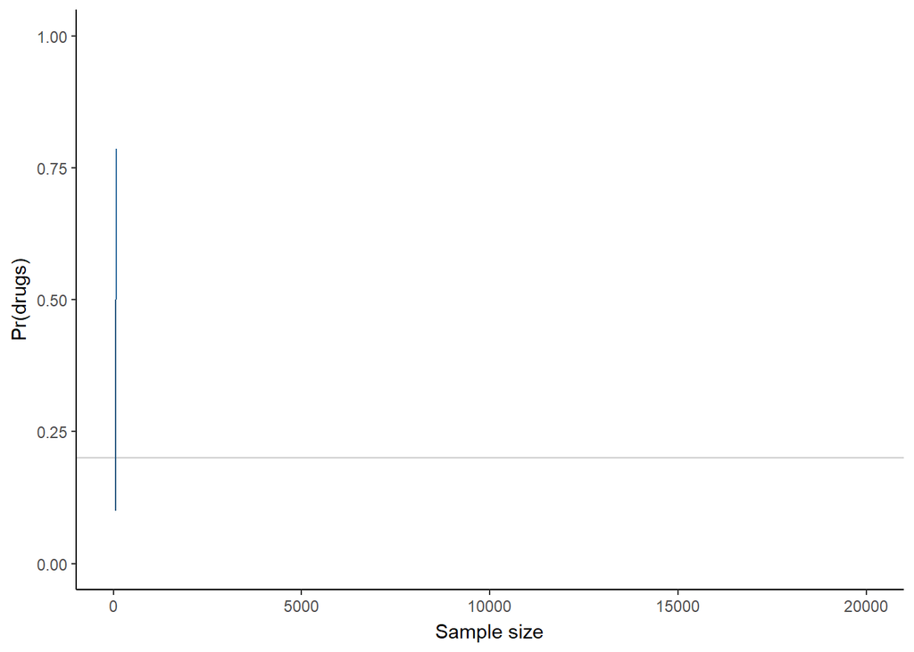

```r
tibble(`Sample size`= 1:2000 * 10,
       `Pr(drugs)` = map_dbl(`Sample size`,
                             ~ rbinom(.x, 1, 0.2) %>%
                               dp(0.1, 0.5) %>%
                               prop_drugs(0.1, 0.5))) %>%
  ggplot(aes(x = `Sample size`, y = `Pr(drugs)`)) +
  geom_hline(yintercept = 0.2, alpha = 0.2) +
  geom_line(aes(group = 1, col = `Pr(drugs)`), size = 0.5) +
  theme_classic() +
  ylim(0,1) +
  transition_reveal(`Sample size`) +
  theme(legend.position = "none")
```

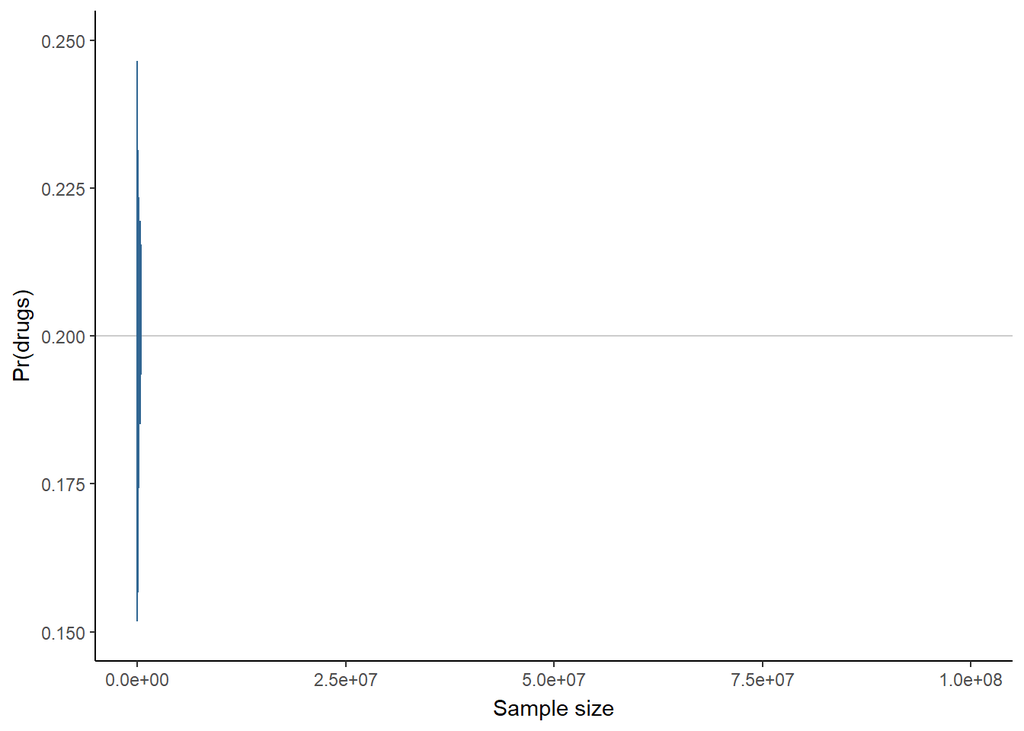

```r
tibble(`Sample size`= seq(from = 1, to = 100, by = 0.1)^4,
       `Pr(drugs)` = map_dbl(`Sample size`,
                             ~ rbinom(.x, 1, 0.2) %>%
                               dp(0.1, 0.5) %>%
                               prop_drugs(0.1, 0.5))) %>%
  ggplot(aes(x = `Sample size`, y = `Pr(drugs)`)) +
  geom_hline(yintercept = 0.2, alpha = 0.2) +
  geom_line(aes(group = 1, col = `Pr(drugs)`), size = 0.5) +
  theme_classic() +
  ylim(0.15,0.25) +
  transition_reveal(`Sample size`) +
  theme(legend.position = "none")
```

The same holds for the sample size. Given the same amount of added noise ($p = 0.1$ in this case), more people allow to obtain a more accurate estimate of the true proportion, even if you only obtain the true estimate of $10\%$ of the cases, and random noise for all others.